# PA2024 field layout inference (for review with Ruairidh)

Fausto Rodriguez

May 14, 2026

# Purpose

The PSU2024 field CSV (`data/PSU2024.csv`) provides per-plot phenotype data with design columns `REP`, `IBLOCK`, `P_SQUARE`, `ROW`, `COLUMN`, but **no absolute field X/Y coordinates**. SpATS spatial correction needs X/Y on a single continuous grid covering all plots.

This notebook documents how those coordinates were inferred from the data and the in-field knowledge that **the smallest plot ID (RS) is at the bottom-left of the field and the maximum at the top-right, with -P treatment on the left and +P on the right**. The resulting offset table is what `Corrected_phenotype_analysis_PSU2024.Rmd` uses in its X/Y derivation.

# 1. Load PSU2024

```r
dat <- read_csv(here("data", "PSU2024.csv"), show_col_types = FALSE) %>%
  mutate(P_LEVEL = factor(P_LEVEL, levels = c("LOW_P", "HIGH_P")))

cat("rows:", nrow(dat), "\n")
```

```
## rows: 960
```

```r
cat("ROW range:    ", range(dat$ROW), "\n")
```

```
## ROW range:     1 10
```

```r
cat("COLUMN range: ", range(dat$COLUMN), "\n")
```

```
## COLUMN range:  1 24
```

```r
cat("REP levels:   ", paste(sort(unique(dat$REP)), collapse = ", "), "\n")
```

```
## REP levels:    1, 2, 3, 4, 5
```

```r
cat("IBLOCK levels:", paste(sort(unique(dat$IBLOCK)), collapse = ", "), "\n")
```

```
## IBLOCK levels: 1, 2, 3, 4, 5, 6, 7, 8
```

```r
cat("P_SQUARE:     ", paste(sort(unique(dat$P_SQUARE)), collapse = ", "), "\n")
```

```
## P_SQUARE:      1, 2, 3, 4
```

```r
cat("P_LEVEL:      ", paste(levels(dat$P_LEVEL), collapse = ", "), "\n")
```

```
## P_LEVEL:       LOW_P, HIGH_P
```

```r
cat("n GENOTYPE:   ", length(unique(dat$GENOTYPE)), "\n")
```

```
## n GENOTYPE:    46
```

```r
cat("RS range:     ", range(dat$RS), "\n")
```

```
## RS range:      2001 2960
```

# 2. Design structure

```r
dat %>% count(REP, P_SQUARE, P_LEVEL) %>% print(n = 30)
```

```
## # A tibble: 20 × 4
##      REP P_SQUARE P_LEVEL     n
##    <dbl>    <dbl> <fct>   <int>
##  1     1        1 LOW_P      48
##  2     1        2 HIGH_P     48
##  3     1        3 LOW_P      48
##  4     1        4 HIGH_P     48
##  5     2        1 LOW_P      48
##  6     2        2 HIGH_P     48
##  7     2        3 LOW_P      48
##  8     2        4 HIGH_P     48
##  9     3        1 LOW_P      48
## 10     3        2 HIGH_P     48
## 11     3        3 LOW_P      48
## 12     3        4 HIGH_P     48
## 13     4        1 LOW_P      48
## 14     4        2 HIGH_P     48
## 15     4        3 LOW_P      48
## 16     4        4 HIGH_P     48
## 17     5        1 LOW_P      48
## 18     5        2 HIGH_P     48
## 19     5        3 LOW_P      48
## 20     5        4 HIGH_P     48
```

5 REPs × 4 P_SQUAREs × 48 plots = 960 plots. P_SQUAREs 1 and 3 are LOW_P, P_SQUAREs 2 and 4 are HIGH_P.

# 3. ROW × COLUMN are local within each P_SQUARE

If `ROW` × `COLUMN` were global field coordinates we’d expect one plot per cell. Counting how many plots share each `(ROW, COLUMN)`:

```r
dat %>% count(ROW, COLUMN) %>%
  count(n, name = "cells_with_this_count")
```

```
## # A tibble: 1 × 2
##       n cells_with_this_count
##   <int>                 <int>
## 1     4                   240
```

```r
dat %>% count(REP, P_SQUARE, ROW, COLUMN) %>%
  count(n, name = "cells_with_this_count")
```

```
## # A tibble: 1 × 2
##       n cells_with_this_count
##   <int>                 <int>
## 1     1                   960
```

Each `(ROW, COLUMN)` is shared by 4 plots — one per P_SQUARE — but `(REP, P_SQUARE, ROW, COLUMN)` is a unique identifier. So **`ROW` and `COLUMN` restart inside each P_SQUARE**, and P_SQUARE is an independent block dimension not captured by the spatial coords alone.

# 4. Plot-ID distribution by P_LEVEL (PSU2024)

```r
dat %>% group_by(P_LEVEL) %>%
  summarise(n = n(), RS_min = min(RS), RS_max = max(RS),
            ID_min = min(ID), ID_max = max(ID))
```

```
## # A tibble: 2 × 6
##   P_LEVEL     n RS_min RS_max ID_min ID_max
##   <fct>   <int>  <dbl>  <dbl>  <dbl>  <dbl>
## 1 LOW_P     480   2001   2720      1    720
## 2 HIGH_P    480   2241   2960    241    960
```

```r
dat %>% group_by(P_SQUARE, P_LEVEL) %>%
  summarise(n = n(), RS_min = min(RS), RS_max = max(RS),
            ID_min = min(ID), ID_max = max(ID), .groups = "drop")
```

```
## # A tibble: 4 × 7
##   P_SQUARE P_LEVEL     n RS_min RS_max ID_min ID_max
##      <dbl> <fct>   <int>  <dbl>  <dbl>  <dbl>  <dbl>
## 1        1 LOW_P     240   2001   2240      1    240
## 2        2 HIGH_P    240   2241   2480    241    480
## 3        3 LOW_P     240   2481   2720    481    720
## 4        4 HIGH_P    240   2721   2960    721    960
```

RS is contiguous within each P_SQUARE — no interleaving. P_SQ 1 = LOW_P (2001-2240), P_SQ 2 = HIGH_P (2241-2480), P_SQ 3 = LOW_P (2481-2720), P_SQ 4 = HIGH_P (2721-2960). The ID-numbering scheme labels the P_SQUAREs but **does not by itself determine their physical arrangement** in the field.

# 5. Cross-check vs PSU2022

PSU2022 used a comparable 4-square design with thousands-digit encoding of P treatment. Same pattern — two LowP blocks and two HighP blocks, each spanning 192 plots (16 IBLOCK × 12 plots):

```r
psu2022 <- read_csv(here("data", "22_NCS_PSU_LANGEBIO_FIELDS_PSU_P_field.csv"),
                    show_col_types = FALSE) %>%
  rename(plot_id = `P22-`)

psu2022 %>% group_by(Treatment) %>%
  summarise(n = n(), id_min = min(plot_id), id_max = max(plot_id))
```

```
## # A tibble: 2 × 4
##   Treatment     n id_min id_max
##   <chr>     <int>  <dbl>  <dbl>
## 1 HighP       384   2001   4192
## 2 LowP        384   1001   3192
```

PSU2022 LowP plots cluster in `1xxx` + `3xxx`, HighP plots in `2xxx` + `4xxx` — the same alternating-block convention. Physical orientation (-P left / +P right) was confirmed by field observation.

# 6. Inferred physical layout — 2×2 of P_SQUAREs

Gives a 2×2 layout:

```
top    | P_SQ 3 (LowP)  | P_SQ 4 (HighP) |   RS 2960 → top-right
bottom | P_SQ 1 (LowP)  | P_SQ 2 (HighP) |   RS 2001 → bottom-left
        ROW 1-10, COL 1-24  ROW 1-10, COL 1-24
```

Assembled field = **20 rows tall × 48 columns wide**.

# 7. X / Y derivation

```r
n_col_psq <- max(dat$COLUMN)   # 24
n_row_psq <- max(dat$ROW)      # 10
psq_x_offset <- c(`1` = 0L, `3` = 0L,
                  `2` = n_col_psq, `4` = n_col_psq)
psq_y_offset <- c(`1` = 0L, `2` = 0L,
                  `3` = n_row_psq, `4` = n_row_psq)

dat <- dat %>%
  mutate(X = psq_x_offset[as.character(P_SQUARE)] + COLUMN,
         Y = psq_y_offset[as.character(P_SQUARE)] + ROW)

dat %>% group_by(P_SQUARE, P_LEVEL) %>%
  summarise(X_range = paste(range(X), collapse = "-"),
            Y_range = paste(range(Y), collapse = "-"),
            .groups = "drop")
```

```
## # A tibble: 4 × 4
##   P_SQUARE P_LEVEL X_range Y_range
##      <dbl> <fct>   <chr>   <chr>
## 1        1 LOW_P   1-24    1-10
## 2        2 HIGH_P  25-48   1-10
## 3        3 LOW_P   1-24    11-20
## 4        4 HIGH_P  25-48   11-20
```

This is the exact offset table copied into `Corrected_phenotype_analysis_PSU2024.Rmd` §2.

# 8. Field maps

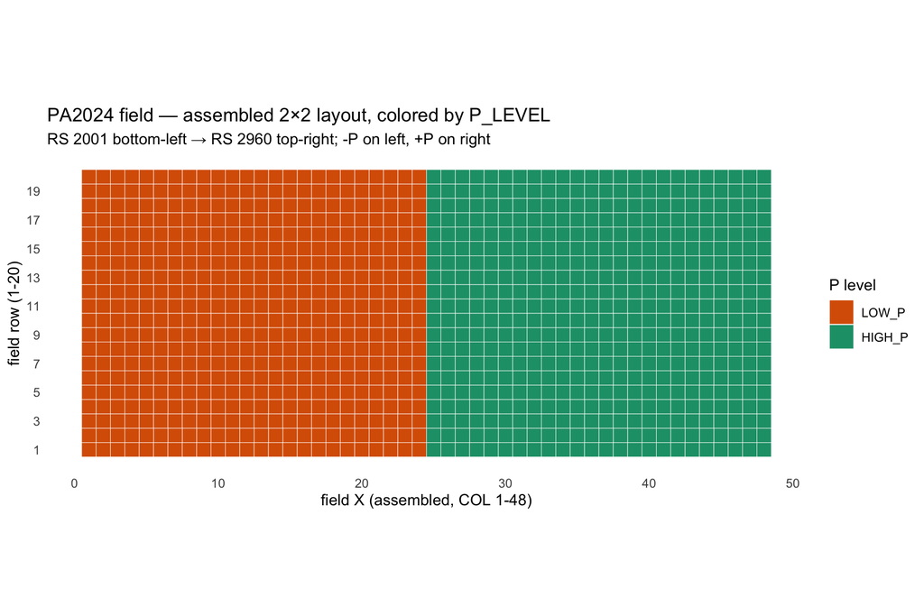

```r
p_lvl <- ggplot(dat, aes(x = X, y = Y, fill = P_LEVEL)) +
  geom_tile(color = "white", linewidth = 0.15) +
  scale_fill_manual(values = c("LOW_P" = "#d95f02", "HIGH_P" = "#1b9e77")) +
  scale_y_continuous(breaks = seq(1, 20, 2)) +
  coord_equal() +
  labs(title = "PA2024 field — assembled 2×2 layout, colored by P_LEVEL",
       subtitle = "RS 2001 bottom-left → RS 2960 top-right; -P on left, +P on right",
       x = "field X (assembled, COL 1-48)", y = "field row (1-20)",
       fill = "P level") +
  theme_minimal(base_size = 11) +
  theme(panel.grid = element_blank())

ggsave(file.path(paths$figures, "PSU2024_layout_by_P_LEVEL.png"),
       p_lvl, width = 9, height = 6, dpi = 150)
p_lvl
```

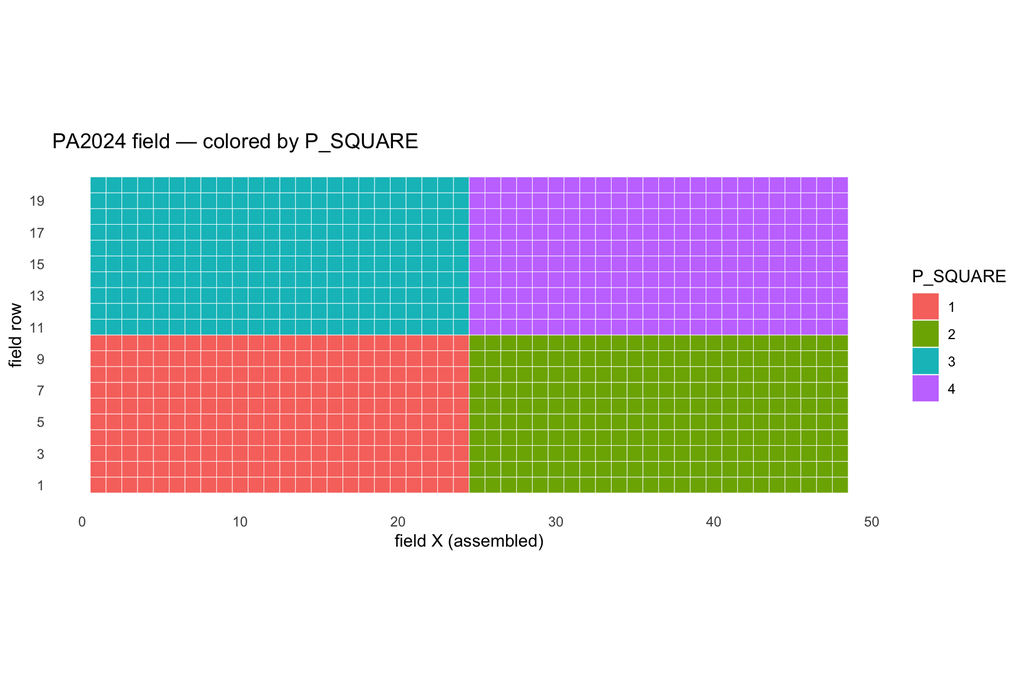

```r
p_sq <- ggplot(dat, aes(x = X, y = Y, fill = factor(P_SQUARE))) +
  geom_tile(color = "white", linewidth = 0.15) +
  scale_y_continuous(breaks = seq(1, 20, 2)) +
  coord_equal() +
  labs(title = "PA2024 field — colored by P_SQUARE",
       x = "field X (assembled)", y = "field row",
       fill = "P_SQUARE") +
  theme_minimal(base_size = 11) +
  theme(panel.grid = element_blank())

ggsave(file.path(paths$figures, "PSU2024_layout_by_P_SQUARE.png"),
       p_sq, width = 9, height = 6, dpi = 150)
p_sq
```

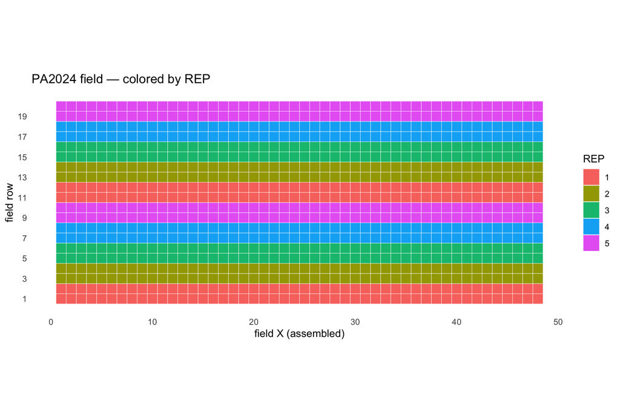

```r
p_rep <- ggplot(dat, aes(x = X, y = Y, fill = factor(REP))) +
  geom_tile(color = "white", linewidth = 0.15) +
  scale_y_continuous(breaks = seq(1, 20, 2)) +
  coord_equal() +
  labs(title = "PA2024 field — colored by REP",
       x = "field X (assembled)", y = "field row",
       fill = "REP") +
  theme_minimal(base_size = 11) +
  theme(panel.grid = element_blank())

ggsave(file.path(paths$figures, "PSU2024_layout_by_REP.png"),
       p_rep, width = 9, height = 6, dpi = 150)
p_rep
```

# 9. RS-at-X/Y grid CSV (for Excel inspection of the serpentine)

Wide-format CSV: rows = field Y (sorted descending so the top of the spreadsheet matches the top of the field), columns = field X (1-48). Each cell holds the RS plot ID at that (X, Y) position.

```r
rs_grid <- dat %>%
  select(X, Y, RS) %>%
  arrange(desc(Y), X) %>%
  pivot_wider(id_cols = Y, names_from = X, values_from = RS,
              names_prefix = "X") %>%
  arrange(desc(Y))

out_csv <- file.path(paths$intermediate, "PSU2024_layout_RS_grid.csv")
write_csv(rs_grid, out_csv)
cat("wrote", out_csv, "\n")
```

```
## wrote /Users/fvrodriguez/Library/CloudStorage/GoogleDrive-frodrig4@ncsu.edu/My Drive/repos/inv4m/results/inversion_paper/intermediate/PSU2024_layout_RS_grid.csv
```

```r
knitr::kable(rs_grid,
             caption = "RS plot ID at each (X, Y); Y descending so top row = top of field.")
```

RS plot ID at each (X, Y); Y descending so top row = top of field.

| Y | X1 | X2 | X3 | X4 | X5 | X6 | X7 | X8 | X9 | X10 | X11 | X12 | X13 | X14 | X15 | X16 | X17 | X18 | X19 | X20 | X21 | X22 | X23 | X24 | X25 | X26 | X27 | X28 | X29 | … |
| --- | --- | --- | --- | --- | --- | --- | --- | --- | --- | --- | --- | --- | --- | --- | --- | --- | --- | --- | --- | --- | --- | --- | --- | --- | --- | --- | --- | --- | --- | --- |
| 20 | 2720 | 2719 | 2718 | 2717 | 2716 | 2715 | 2714 | 2713 | 2712 | 2711 | 2710 | 2709 | 2708 | 2707 | 2706 | 2705 | 2704 | 2703 | 2702 | 2701 | 2700 | 2699 | 2698 | 2697 | 2960 | 2959 | 2958 | 2957 | 2956 | … |
| 19 | 2673 | 2674 | 2675 | 2676 | 2677 | 2678 | 2679 | 2680 | 2681 | 2682 | 2683 | 2684 | 2685 | 2686 | 2687 | 2688 | 2689 | 2690 | 2691 | 2692 | 2693 | 2694 | 2695 | 2696 | 2913 | 2914 | 2915 | 2916 | 2917 | … |
| 18 | 2672 | 2671 | 2670 | 2669 | 2668 | 2667 | 2666 | 2665 | 2664 | 2663 | 2662 | 2661 | 2660 | 2659 | 2658 | 2657 | 2656 | 2655 | 2654 | 2653 | 2652 | 2651 | 2650 | 2649 | 2912 | 2911 | 2910 | 2909 | 2908 | … |
| 17 | 2625 | 2626 | 2627 | 2628 | 2629 | 2630 | 2631 | 2632 | 2633 | 2634 | 2635 | 2636 | 2637 | 2638 | 2639 | 2640 | 2641 | 2642 | 2643 | 2644 | 2645 | 2646 | 2647 | 2648 | 2865 | 2866 | 2867 | 2868 | 2869 | … |
| 16 | 2624 | 2623 | 2622 | 2621 | 2620 | 2619 | 2618 | 2617 | 2616 | 2615 | 2614 | 2613 | 2612 | 2611 | 2610 | 2609 | 2608 | 2607 | 2606 | 2605 | 2604 | 2603 | 2602 | 2601 | 2864 | 2863 | 2862 | 2861 | 2860 | … |
| 15 | 2577 | 2578 | 2579 | 2580 | 2581 | 2582 | 2583 | 2584 | 2585 | 2586 | 2587 | 2588 | 2589 | 2590 | 2591 | 2592 | 2593 | 2594 | 2595 | 2596 | 2597 | 2598 | 2599 | 2600 | 2817 | 2818 | 2819 | 2820 | 2821 | … |
| 14 | 2576 | 2575 | 2574 | 2573 | 2572 | 2571 | 2570 | 2569 | 2568 | 2567 | 2566 | 2565 | 2564 | 2563 | 2562 | 2561 | 2560 | 2559 | 2558 | 2557 | 2556 | 2555 | 2554 | 2553 | 2816 | 2815 | 2814 | 2813 | 2812 | … |
| 13 | 2529 | 2530 | 2531 | 2532 | 2533 | 2534 | 2535 | 2536 | 2537 | 2538 | 2539 | 2540 | 2541 | 2542 | 2543 | 2544 | 2545 | 2546 | 2547 | 2548 | 2549 | 2550 | 2551 | 2552 | 2769 | 2770 | 2771 | 2772 | 2773 | … |
| 12 | 2528 | 2527 | 2526 | 2525 | 2524 | 2523 | 2522 | 2521 | 2520 | 2519 | 2518 | 2517 | 2516 | 2515 | 2514 | 2513 | 2512 | 2511 | 2510 | 2509 | 2508 | 2507 | 2506 | 2505 | 2768 | 2767 | 2766 | 2765 | 2764 | … |
| 11 | 2481 | 2482 | 2483 | 2484 | 2485 | 2486 | 2487 | 2488 | 2489 | 2490 | 2491 | 2492 | 2493 | 2494 | 2495 | 2496 | 2497 | 2498 | 2499 | 2500 | 2501 | 2502 | 2503 | 2504 | 2721 | 2722 | 2723 | 2724 | 2725 | … |
| 10 | 2240 | 2239 | 2238 | 2237 | 2236 | 2235 | 2234 | 2233 | 2232 | 2231 | 2230 | 2229 | 2228 | 2227 | 2226 | 2225 | 2224 | 2223 | 2222 | 2221 | 2220 | 2219 | 2218 | 2217 | 2480 | 2479 | 2478 | 2477 | 2476 | … |
| 9 | 2193 | 2194 | 2195 | 2196 | 2197 | 2198 | 2199 | 2200 | 2201 | 2202 | 2203 | 2204 | 2205 | 2206 | 2207 | 2208 | 2209 | 2210 | 2211 | 2212 | 2213 | 2214 | 2215 | 2216 | 2433 | 2434 | 2435 | 2436 | 2437 | … |
| 8 | 2192 | 2191 | 2190 | 2189 | 2188 | 2187 | 2186 | 2185 | 2184 | 2183 | 2182 | 2181 | 2180 | 2179 | 2178 | 2177 | 2176 | 2175 | 2174 | 2173 | 2172 | 2171 | 2170 | 2169 | 2432 | 2431 | 2430 | 2429 | 2428 | … |
| 7 | 2145 | 2146 | 2147 | 2148 | 2149 | 2150 | 2151 | 2152 | 2153 | 2154 | 2155 | 2156 | 2157 | 2158 | 2159 | 2160 | 2161 | 2162 | 2163 | 2164 | 2165 | 2166 | 2167 | 2168 | 2385 | 2386 | 2387 | 2388 | 2389 | … |
| 6 | 2144 | 2143 | 2142 | 2141 | 2140 | 2139 | 2138 | 2137 | 2136 | 2135 | 2134 | 2133 | 2132 | 2131 | 2130 | 2129 | 2128 | 2127 | 2126 | 2125 | 2124 | 2123 | 2122 | 2121 | 2384 | 2383 | 2382 | 2381 | 2380 | … |
| 5 | 2097 | 2098 | 2099 | 2100 | 2101 | 2102 | 2103 | 2104 | 2105 | 2106 | 2107 | 2108 | 2109 | 2110 | 2111 | 2112 | 2113 | 2114 | 2115 | 2116 | 2117 | 2118 | 2119 | 2120 | 2337 | 2338 | 2339 | 2340 | 2341 | … |
| 4 | 2096 | 2095 | 2094 | 2093 | 2092 | 2091 | 2090 | 2089 | 2088 | 2087 | 2086 | 2085 | 2084 | 2083 | 2082 | 2081 | 2080 | 2079 | 2078 | 2077 | 2076 | 2075 | 2074 | 2073 | 2336 | 2335 | 2334 | 2333 | 2332 | … |
| 3 | 2049 | 2050 | 2051 | 2052 | 2053 | 2054 | 2055 | 2056 | 2057 | 2058 | 2059 | 2060 | 2061 | 2062 | 2063 | 2064 | 2065 | 2066 | 2067 | 2068 | 2069 | 2070 | 2071 | 2072 | 2289 | 2290 | 2291 | 2292 | 2293 | … |
| 2 | 2048 | 2047 | 2046 | 2045 | 2044 | 2043 | 2042 | 2041 | 2040 | 2039 | 2038 | 2037 | 2036 | 2035 | 2034 | 2033 | 2032 | 2031 | 2030 | 2029 | 2028 | 2027 | 2026 | 2025 | 2288 | 2287 | 2286 | 2285 | 2284 | … |
| 1 | 2001 | 2002 | 2003 | 2004 | 2005 | 2006 | 2007 | 2008 | 2009 | 2010 | 2011 | 2012 | 2013 | 2014 | 2015 | 2016 | 2017 | 2018 | 2019 | 2020 | 2021 | 2022 | 2023 | 2024 | 2241 | 2242 | 2243 | 2244 | 2245 | … |

# 10. Notes for review

This layout interpretation rests on two pieces of in-field knowledge:

1. **Smallest RS (2001) → physical bottom-left; largest RS (2960) → top-right.**
2. **LowP on the left half, HighP on the right.**

If either is wrong, the offset table at §7 needs to change. Specifically:

- If the layout is taller than wide (transposed), swap X ↔︎ Y in §7.
- If P_SQUARE 1 is *top*-left rather than bottom-left, swap the Y offsets.
- If LowP and HighP squares are interleaved (1-2-3-4 left-to-right) rather than side-by-side (1-3 left, 2-4 right), the X offsets need to be permuted.

The downstream analysis (`Corrected_phenotype_analysis_PSU2024.Rmd`) uses these X/Y as the SpATS spatial coords with no further assumptions about plot positions, so a wrong layout would manifest as a poor SpATS surface fit (and visibly weird spatial residual plots).